# A Protocol for Data Exploration

Anthony Waite

20/01/2020

# Introduction

Undertaking a systematic data exploration prior to applying statistical analysis techniques to experimental data can help improve the statistical validity of results and associated conclusons. Key to this is a protocol for ensuring the scientist does not discover a false covariate effect (*type I error*) or wrongly dismiss a model was valid covariate (*type II error*).

The aim of this vignette is to provide a protocol for data exploration that identifies potential problems before any statistical analysis is undertaken. The approach outlined makes extensive use of the material discussed in [^1]. Datasets are sourced from the Internet or academics at Oxford Brookes University.

# Are there outliers?

In some statistical techniques the results are dominated by outliers; other techniques treat them like any other value. For example, outliers may cause overdispersion in a Poisson GLM. Outliers are defined as an observation that has a relatively large or small value compared to the majority of observations.

In order to demonstrate the data exploration step we will use data from species group sizes in the Naboisho Conservancy within Kenya. Here researchers recorded the size of species groups as they drove along a number of 2km transects.

## Boxplots

```r
library(ggplot2)
library(dplyr)
naboisho %>%
  filter(species != "None") %>%
  ggplot(aes(x=species, y=log10(size))) +
  geom_boxplot(outlier.colour="red",
               outlier.shape=16,
               outlier.size=0.75,
               notch=F) +
  coord_flip() +
  ggtitle("Species group sizes in Naboisho Conservancy. 2016 to 2019") +
  xlab("Species") +
  ylab("Species group size - log10") +
  theme_bw()
```

[output not shown]

Note the x axis is scaled to log base 10, in order to compare species with small group sizes, such as Black Backed Jackal, against species with large group sizes such as Zebra or Wildebeest.

## Cleveland dot plot

**Cleveland dotplot** is a chart in which the row number of an observation is plotted vs. the observation value, thereby providing a more detailed view of individual observations than a boxplot allows. Points that stick out on the right-hand side, or on the left-hand side, are observed values that are considerable larger, or smaller, than the majority of the observations, and require further investigation. Below we have taken all observations for Giraffe group size from the Naboisho dataset, and plotted them within a Cleveland dot plot.

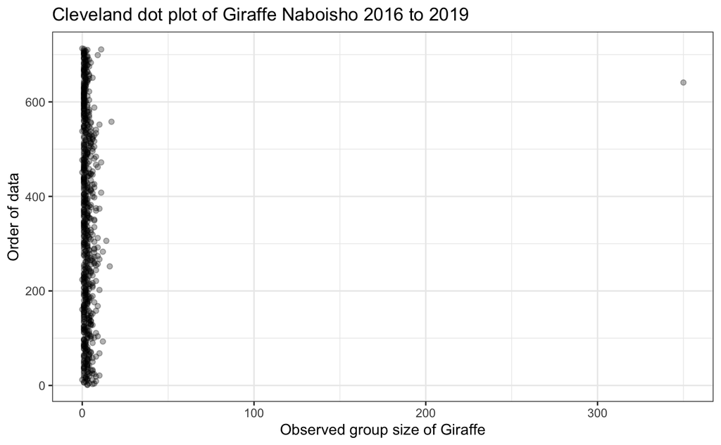

```r
naboisho %>%
  filter(species == "Giraffe") %>%
  ggplot(aes(x=size, y=seq(1, length(size)))) +
  geom_point(alpha=0.3) +
  ggtitle("Cleveland dot plot of Giraffe Naboisho 2016 to 2019") +
  labs(x = "Observed group size of Giraffe",
       y = "Order of data") +
  theme_bw()
```

We can see that there is a single outlier; a group size of 350 Giraffe. This is quite clearly a data entry error. If we remove this outlier and replot the dot plot, we see the following:

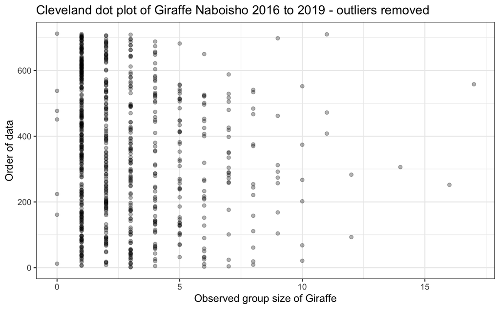

```r
naboisho %>%
  filter(species == "Giraffe") %>%
  filter(size <= 300) %>%
  ggplot(aes(x=size, y=seq(1, length(size)))) +
  geom_point(alpha=0.3) +
  ggtitle("Cleveland dot plot of Giraffe Naboisho 2016 to 2019 - outliers removed") +
  labs(x = "Observed group size of Giraffe",
       y = "Order of data") +
  theme_bw()
```

Note we also have a number of observations with group sizing of zero. This is clearly not possible and is probably due to a misunderstanding on behalf of the data recroder, and should be corrected to equal 1.

## Implications

Having determined that there are outliers in observations, we can take a number of steps to validate their inclusion or not:

- check the data to ensure that there has not been a data entry error
- check the scientific literature to provide an expected value.
- generate a number of observations randomly from an appropriate distribution, and determine how the proportion of extremem points compares to the field data

# Homogeneity of variance

Homogeneity of variance is an important assumption in analysis of variance (ANOVA). The plot below shows a boxplot for Wildebesst group size observations within the Naboisho dataset. In the plots below we have assumed that the long rains are from April to May, the short rains are in Novemeber and all other months are the dry season.

To apply ANOVA to these data to determine if mean Wildebeest group size varies by year, season or a combination of year and season, we must assume that variation:

1. In the years are similar
2. In observations for each season are similar
3. Between seasons within years are similar.

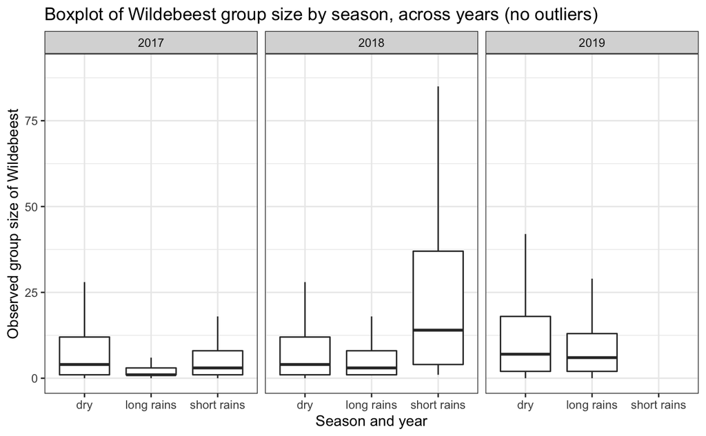

```r
library(lubridate)
# Add a column to the data set to determine month of year
wildebeest_seasons <- naboisho %>%
  mutate(Month = month(Date, label= T, abbr = T)) %>%
  # Add a season column to data
  mutate(season = case_when(
    Month == "Apr" ~ "long rains",
    Month == "May" ~ "long rains",
    Month == "Nov" ~ "short rains",
    TRUE           ~ "dry")) %>% # Else it's the dry season
  # Take Widebeest only
  filter(species == "Wildebeest") %>%
  # Filter out 2016 as insufficient data to determine month
  filter(year != 2016)
wildebeest_seasons %>%
  # Plot boxplots by season, don't display outliers
  ggplot(aes(x=season, y=size)) +
    geom_boxplot(outlier.shape=NA) +
    # Facet by year
    facet_wrap(. ~ year) +
    coord_cartesian(ylim=c(0, 90)) +
    theme_bw() +
    ggtitle("Boxplot of Wildebeest group size by season, across years (no outliers)") +
    labs(x = "Season and year",
         y = "Observed group size of Wildebeest")
```

```r
library(car)
# Generate a two-way test to incorporate interaction between seasons and years
leveneTest(size ~ as.factor(season) * as.factor(year), data = wildebeest_seasons)
```

```
Levene's Test for Homogeneity of Variance (center = median)
        Df F value    Pr(>F)
group    7  19.531 < 2.2e-16 ***
      9747
---
Signif. codes:  0 ‘***’ 0.001 ‘**’ 0.01 ‘*’ 0.05 ‘.’ 0.1 ‘ ’ 1
```

From the output above we can see that the p-value is much less than the significance level of 0.05. This means that we can not assume equal variances betweens years and seasons. The Levene test is significant.

```r
wildebeest_seasons %>%
  mutate_all(funs(replace(.,.==0,1))) %>%
  aov(log(size) ~ as.factor(season) * as.factor(year), data = .) -> test.aov

aov_residuals <- residuals(object = test.aov) %>%
  hist(breaks=200)
```

[output not shown]

## Implications

Statistical modelling using regression will assume homogenous variance. This can be checked by plotting the model residuals against the fitted values. A good fit will have have similar residual variation across all values. In order to address heterogeneity of variance in the response variable, it can be transformed. For example a log transformation.

[figure not shown]

## Implications

In regression-type models, verification of homogeneity should be done using the residuals of the model; i.e. by plotting residuals vs. fitted values, and making a similar set of conditional boxplots for the residuals. In all these graphs the residual variation should be similar. The solution to heterogeneity of variance is either a transformation of the response variable to stabilize the variance, or applying statistical techniques that do not require homogeneity (e.g. generalized least squares)

# Are the data normally distributed?

```r
ggplot(sparrows, aes(x = Wt)) +
  geom_histogram(color = "black") +
    theme_minimal() +
    labs(x = "Weight (g)",
         y = "Frequency")
```

[output not shown]

# Are there a significant number of zeros in the data?

```r
ggplot(waders, aes(x = OC)) +
  geom_histogram(color = "black") +
  theme_minimal() +
    labs(x = "Observed count of Oyster Catchers",
         y = "Frequency")
```

[output not shown]

The extremely high number of zeros tells us that we should not apply an ordinary Poisson or negative binomial GLM as these would produce biased parameter estimates and standard errors. Instead one should consider zero inflated GLMs.

## Implications for species abundance

```r
library(corrgram)
waders %>%
  select(c("CU","L","OC","RK","SN")) %>%
  na.omit() %>%
  mutate_all(function(x) as.numeric(as.character(x))) %>%
  corrgram(order=T, upper.panel=panel.pie)
```

[output not shown]

# References

[^1]: Zuur AF, Leno EN, Elphick CS (2010) A protocol for data exploration to avoid common statistical problems. *Methods in Ecology and Evolution*